# Aides Drug

Johanna Iniguez!

10/30/2019

# Introduction

A new preventative aides (abacavirinol) is under test in clinical trials. Analyze the effectiveness of this drug across the board. Consider population subgroups by gender, drug use, and sexual orientation. Finish this!

Our data came from Tigerstats from a research done in Asia. Our general research question is whether the vaccine if effective for preventing AIDS across the board while considering subgroups by gender, drug use, and sexual orientation.

For each of the five tests which include: testing for vaccine effectiveness in total population, testing for vaccine effectiveness in female population, testing for vaccine effectiveness in male population,testing for vaccine effectiveness in drug users population, and testing for vaccine effectiveness in LGBTQ population. Response is categorical, the factor is categorical so we use bar graphs to graphically show the data, and a cross-tabulation for a numerical summary. A chi-squared test will be used to infer whether or not there is a relationship between the variables.

# Methods

## Question 1: Is the vaccine effective for the total population ?

$H_0$ the vaccine has no effect on whether one contracts AIDS or not  
$H_1$ the vaccine affects whether on contracts AIDS or not

# Results

## Descriptive Results

### Graphical Descriptive Results

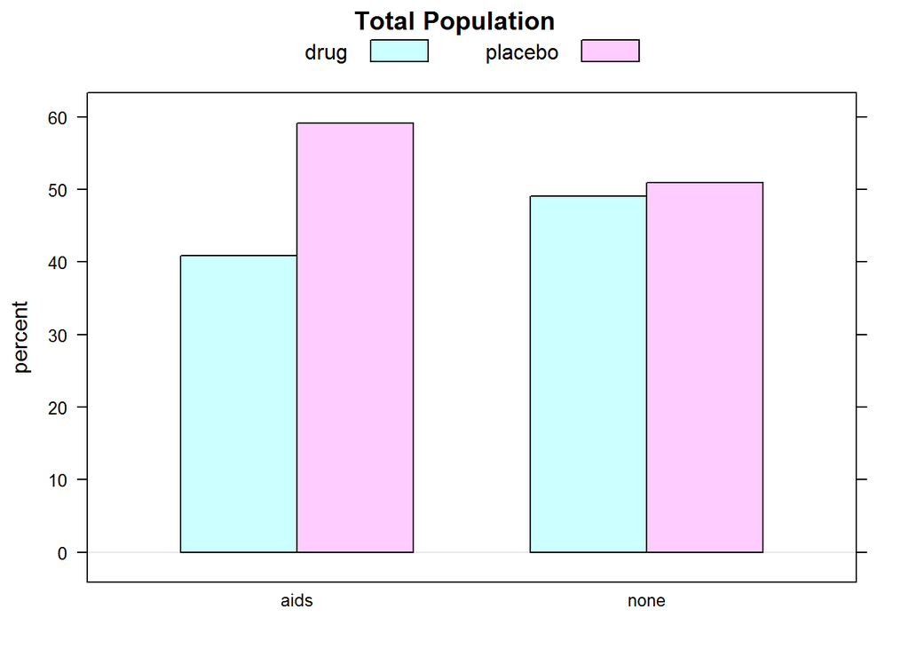

```r
barchartGC(~infected + treatment, data = avast, main= 'Total Population', type= 'percent')
```

This barchart shows among the total population that contracted AIDS, fewer of them contracted AIDS while taking the vaccine than the population that contracted AIDS while taking the placebo so there is a vaccine effectiveness.

### Numerical Descriptive Results

```r
allPeople = xtabs(~infected + treatment, data = avast)
rowPerc(allPeople)
```

```
##         treatment
## infected   drug placebo  Total
##     aids  40.87   59.13 100.00
##     none  49.10   50.90 100.00
```

This table shows among the population who got AIDS, about 41 percent of them had the vaccine, while about 59 percent were given the placebo.

## Inferential Results

```r
chisqtestGC(allPeople, data = avast)
```

```
## Pearson's Chi-squared test with Yates' continuity correction
##
## Observed Counts:
##         treatment
## infected  drug placebo
##     aids   423     612
##     none 10168   10540
##
## Counts Expected by Null:
##         treatment
## infected     drug  placebo
##     aids   504.15   530.85
##     none 10086.85 10621.15
##
## Contributions to the chi-square statistic:
##         treatment
## infected  drug placebo
##     aids 13.06   12.40
##     none  0.65    0.62
##
##
## Chi-Square Statistic = 26.4104
## Degrees of Freedom of the table = 1
## P-Value = 0
```

The P value is 0.

# Discussion and Conclusion

The P-Value is 0 which is less than 0.05 so we reject the null hypothesis and conlcude that the vaccine has an effect on whether one contracts AIDS or not within the total population.

# Introduction

A new preventative aides (abacavirinol) is under test in clinical trials. Analyze the effectiveness of this drug across the board. Consider population subgroups by gender, drug use, and sexual orientation. Finish this!

Our data came from Tigerstats from a research done in Asia. Our general research question is whether the vaccine if effective for preventing AIDS across the board while considering subgroups by gender, drug use, and sexual orientation.

For each of the five tests which include: testing for vaccine effectiveness in total population, testing for vaccine effectiveness in female population, testing for vaccine effectiveness in male population,testing for vaccine effectiveness in drug users population, and testing for vaccine effectiveness in LGBTQ population. Response is categorical, the factor is categorical so we use bar graphs to graphically show the data, and a cross-tabulation for a numerical summary. A chi-squared test will be used to infer whether or not there is a relationship between the variables.

# Methods

## Question 2: Is the vaccine effective for the Female population ?

$H_0$ the vaccine has no effect on whether one contracts AIDS or not  
$H_1$ the vaccine affects whether on contracts AIDS or not

# Results

## Descriptive Results

### Graphical Descriptive Results

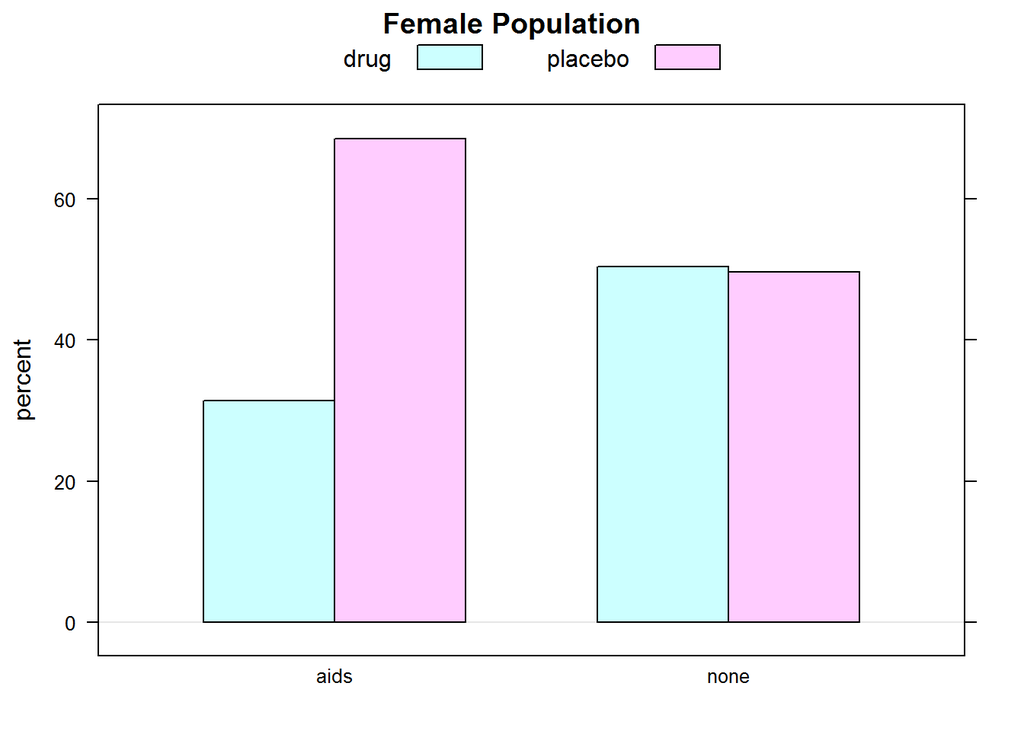

```r
gal = filter(avast, sex == 'gal')
barchartGC(~infected + treatment, data = filter (avast, sex == 'gal') , main= 'Female Population', type= 'percent')
```

This barchart shows among the female population that contracted AIDS, fewer of them contracted AIDS while taking the vaccine than the female population that contracted AIDS while taking the placebo,so there is a vaccine effectiveness.

### Numerical Descriptive Results

```r
gal = xtabs(~infected + treatment, data = filter(avast,sex=='gal'))
rowPerc(gal)
```

```
##         treatment
## infected   drug placebo  Total
##     aids  31.42   68.58 100.00
##     none  50.38   49.62 100.00
```

This table shows among the female population who got AIDS, about 31 percent of them had the vaccine, while about 69 percent were given the placebo.

## Inferential Results

```r
chisqtestGC(gal, data = avast)
```

```
## Pearson's Chi-squared test with Yates' continuity correction
##
## Observed Counts:
##         treatment
## infected drug placebo
##     aids  213     465
##     none 4684    4613
##
## Counts Expected by Null:
##         treatment
## infected    drug placebo
##     aids  332.85  345.15
##     none 4564.15 4732.85
##
## Contributions to the chi-square statistic:
##         treatment
## infected  drug placebo
##     aids 43.15   41.62
##     none  3.15    3.03
##
##
## Chi-Square Statistic = 90.1943
## Degrees of Freedom of the table = 1
## P-Value = 0
```

The P value is 0.

# Discussion and Conclusion

The P-Value is 0 which is less than 0.5 so we reject the null hypothesis and conclude that the vaccine has an effect on whether one contracts AIDS or not within the female population.

# Introduction

A new preventative aides (abacavirinol) is under test in clinical trials. Analyze the effectiveness of this drug across the board. Consider population subgroups by gender, drug use, and sexual orientation. Finish this!

Our data came from Tigerstats from a research done in Asia. Our general research question is whether the vaccine if effective for preventing AIDS across the board while considering subgroups by gender, drug use, and sexual orientation.

For each of the five tests which include: testing for vaccine effectiveness in total population, testing for vaccine effectiveness in female population, testing for vaccine effectiveness in male population,testing for vaccine effectiveness in drug users population, and testing for vaccine effectiveness in LGBTQ population. Response is categorical, the factor is categorical so we use bar graphs to graphically show the data, and a cross-tabulation for a numerical summary. A chi-squared test will be used to infer whether or not there is a relationship between the variables.

# Methods

## Question 3: Is the vaccine effective for the Male population ?

$H_0$ the vaccine has no effect on whether one contracts AIDS or not  
$H_1$ the vaccine affects whether on contracts AIDS or not

# Results

## Descriptive Results

### Graphical Descriptive Results

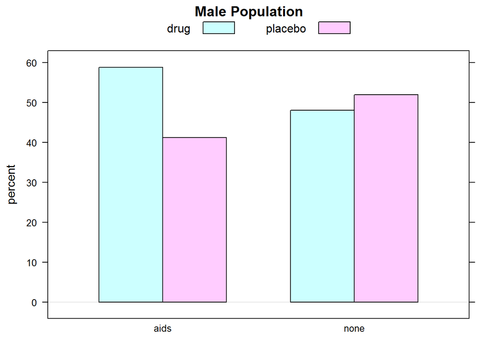

```r
guy = filter(avast, sex == 'guy')
barchartGC(~infected + treatment, data = filter (avast, sex == 'guy') , main= 'Male Population', type= 'percent')
```

### Numerical Descriptive Results

```r
guy = xtabs(~infected + treatment, data = filter(avast,sex=='guy'))
rowPerc(guy)
```

```
##         treatment
## infected   drug placebo  Total
##     aids  58.82   41.18 100.00
##     none  48.06   51.94 100.00
```

This table shows among the male population who got AIDS, about 59 percent of them had the vaccine while about 41 percent were given the placebo.

## Inferential Results

```r
chisqtestGC(guy, data = filter)
```

```
## Pearson's Chi-squared test with Yates' continuity correction
##
## Observed Counts:
##         treatment
## infected drug placebo
##     aids  210     147
##     none 5484    5927
##
## Counts Expected by Null:
##         treatment
## infected    drug placebo
##     aids  172.74  184.26
##     none 5521.26 5889.74
##
## Contributions to the chi-square statistic:
##         treatment
## infected drug placebo
##     aids 8.04    7.54
##     none 0.25    0.24
##
##
## Chi-Square Statistic = 15.6339
## Degrees of Freedom of the table = 1
## P-Value = 1e-04
```

The P value is .0001

# Discussion and Conclusion

The P-Value is .0001 which is less than 0.5 so we reject the null hypothesis and conclude that we have enough evidence to prove that the vaccine makes males more susceptible to contracting AIDS.

# Introduction

A new preventative aides (abacavirinol) is under test in clinical trials. Analyze the effectiveness of this drug across the board. Consider population subgroups by gender, drug use, and sexual orientation. Finish this!

Our data came from Tigerstats from a research done in Asia. Our general research question is whether the vaccine if effective for preventing AIDS across the board while considering subgroups by gender, drug use, and sexual orientation.

For each of the five tests which include: testing for vaccine effectiveness in total population, testing for vaccine effectiveness in female population, testing for vaccine effectiveness in male population,testing for vaccine effectiveness in drug users population, and testing for vaccine effectiveness in LGBTQ population. Response is categorical, the factor is categorical so we use bar graphs to graphically show the data, and a cross-tabulation for a numerical summary. A chi-squared test will be used to infer whether or not there is a relationship between the variables.

# Methods

## Question 4: Is the vaccine effective for the Drug Users population ?

$H_0$ the vaccine has no effect on whether one contracts AIDS or not  
$H_1$ the vaccine affects whether on contracts AIDS or not

# Results

## Descriptive Results

### Graphical Descriptive Results

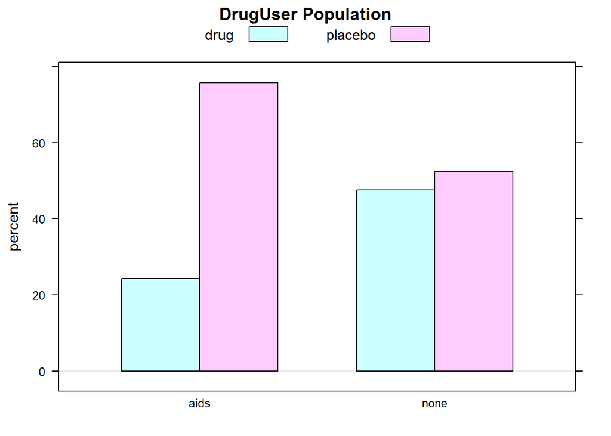

```r
DrugUser = filter(avast, DrugUser == 'yes')
barchartGC(~infected + treatment, data = filter (avast, DrugUser == 'yes') , main= 'DrugUser Population', type= 'percent')
```

This barchart shows among the drug users population that contracted AIDS, fewer of them contracted AIDS while taking the vaccine than the drug users population that contracted AIDS while taking the placebo so there is a vaccine effectiveness.

### Numerical Descriptive Results

```r
table1 <- xtabs(~infected + treatment, data = filter (avast, DrugUser == 'yes'))
rowPerc(table1)
```

```
##         treatment
## infected   drug placebo  Total
##     aids  24.29   75.71 100.00
##     none  47.59   52.41 100.00
```

This table shows among the drug users population who got AIDS, about 24 percent of them had the vaccine, while about 76 percent were given the placebo.

## Inferential Results

```r
chisqtestGC(table1)
```

```
## Pearson's Chi-squared test with Yates' continuity correction
##
## Observed Counts:
##         treatment
## infected drug placebo
##     aids   34     106
##     none 1143    1259
##
## Counts Expected by Null:
##         treatment
## infected    drug placebo
##     aids   64.82   75.18
##     none 1112.18 1289.82
##
## Contributions to the chi-square statistic:
##         treatment
## infected  drug placebo
##     aids 14.66   12.64
##     none  0.85    0.74
##
##
## Chi-Square Statistic = 27.955
## Degrees of Freedom of the table = 1
## P-Value = 0
```

The P value is 0.

# Discussion and Conclusion

The P-Value is 0 which is less than 0.5 so we reject the null hypothesis and conclude that the vaccine has an effect on whether one contracts AIDS or not within the drug users population.

# Introduction

A new preventative aides (abacavirinol) is under test in clinical trials. Analyze the effectiveness of this drug across the board. Consider population subgroups by gender, drug use, and sexual orientation. Finish this!

Our data came from Tigerstats from a research done in Asia. Our general research question is whether the vaccine if effective for preventing AIDS across the board while considering subgroups by gender, drug use, and sexual orientation.

For each of the five tests which include: testing for vaccine effectiveness in total population, testing for vaccine effectiveness in female population, testing for vaccine effectiveness in male population,testing for vaccine effectiveness in drug users population, and testing for vaccine effectiveness in LGBTQ population. Response is categorical, the factor is categorical so we use bar graphs to graphically show the data, and a cross-tabulation for a numerical summary. A chi-squared test will be used to infer whether or not there is a relationship between the variables.

# Methods

## Question 5: Is the vaccine effective for the LGBTQ population ?

$H_0$ the vaccine has no effect on whether one contracts AIDS or not  
$H_1$ the vaccine affects whether on contracts AIDS or not

# Results

## Descriptive Results

### Graphical Descriptive Results

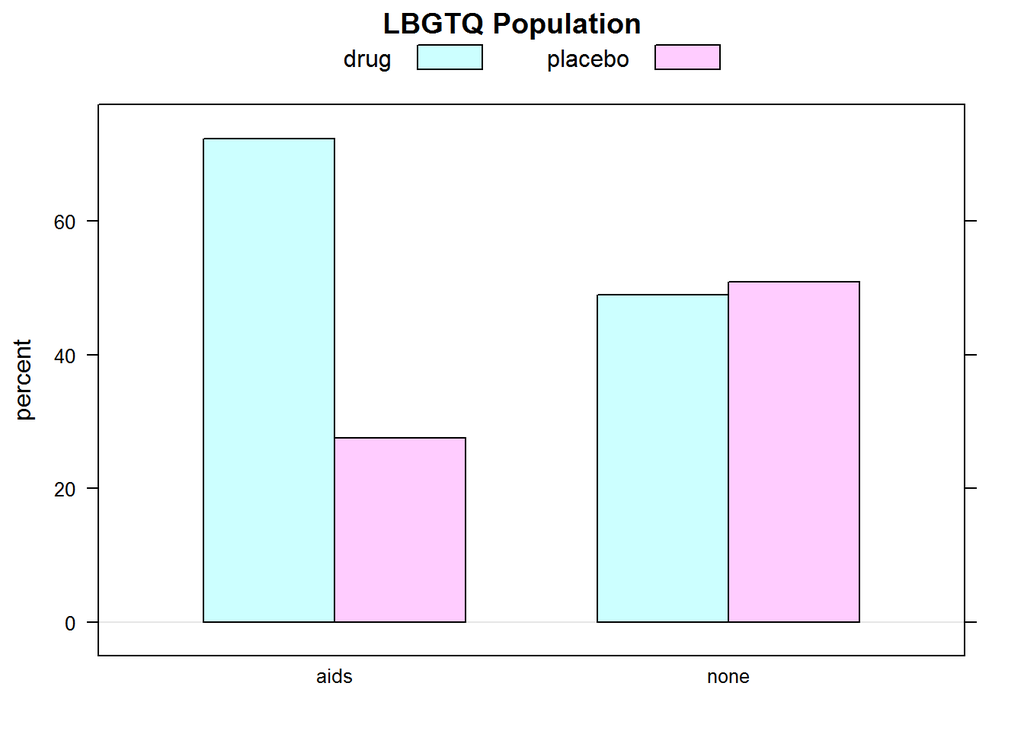

```r
barchartGC(~infected + treatment, data = filter (avast, LGBTQ == 'gay') , main= 'LBGTQ Population', type= 'percent')
```

This barchart shows among the LGBTQ population that contracted AIDS, more of them contracted AIDS while taking the vaccine than the LGBTQ population that contracted AIDS while taking the placebo so there is vaccine effectiveness that makes LGBTQ more susceptible to contracting AIDS.

### Numerical Descriptive Results

```r
Table4 = xtabs(~infected + treatment, data = filter (avast, LGBTQ == 'gay'))
rowPerc(Table4)
```

```
##         treatment
## infected   drug placebo  Total
##     aids  72.38   27.62 100.00
##     none  49.05   50.95 100.00
```

This table shows among the LGTBQ population that contracted AIDS, about 72 percent of them had the vaccine, while about 28 percent were given the placebo.

## Inferential Results

```r
chisqtestGC(Table4)
```

```
## Pearson's Chi-squared test with Yates' continuity correction
##
## Observed Counts:
##         treatment
## infected drug placebo
##     aids   76      29
##     none 1007    1046
##
## Counts Expected by Null:
##         treatment
## infected    drug placebo
##     aids   52.69   52.31
##     none 1030.31 1022.69
##
## Contributions to the chi-square statistic:
##         treatment
## infected  drug placebo
##     aids 10.31   10.38
##     none  0.53    0.53
##
##
## Chi-Square Statistic = 20.8264
## Degrees of Freedom of the table = 1
## P-Value = 0
```

The P value is 0.

# Discussion and Conclusion

The P-Value is 0 which is less than 0.5 so we reject the null hypothesis and conclude that we have enough evidence to prove that the vaccine makes LGBTQ population more susceptible to contracting AIDS.